# Homework 3

Forecasting: Principles and Practice - Time Series Decomposition

Paul Perez

2/28/2021

# Exercise 6.9 - 2

The `plastics` data set consists of the monthly sales (in thousands) of product A for a plastics manufacturer for five years.

## a. Plot the time series of sales of product A. Can you identify seasonal fluctuations and/or a trend-cycle?

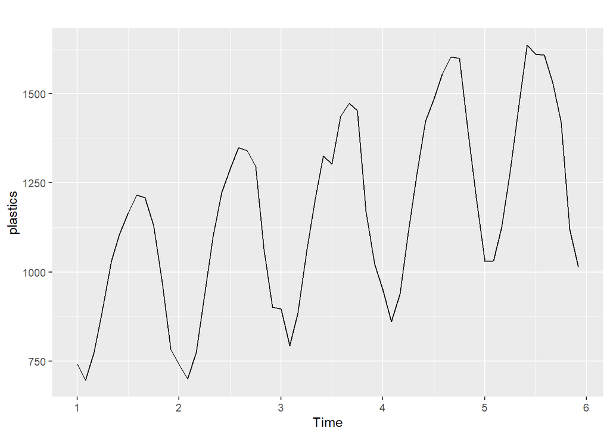

```r
autoplot(plastics)
```

The `plastics` dataset over the course of 5 years shows an upward trend. Additionally, the data looks cyclical and seasonal as the mid-year months have greater sales than those of the earlier and later months of the year.

## b. Use a classifical multiplicative decomposition to calculate the trend-cycle and seasonal indices.

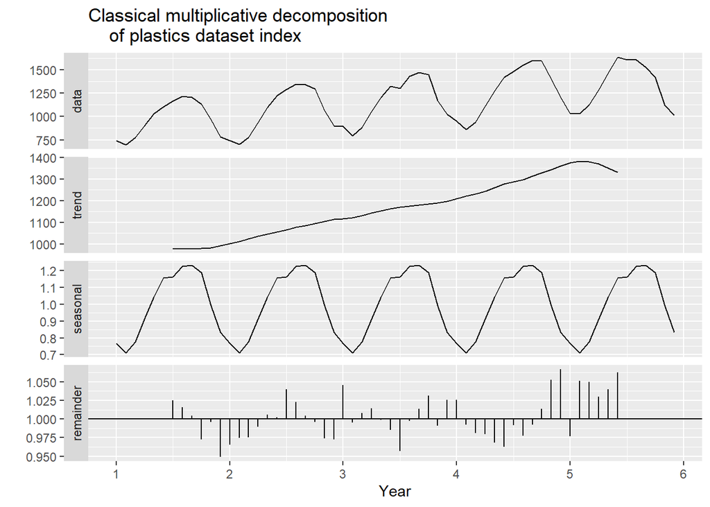

```r
plastics %>% decompose(type="multiplicative") %>%
  autoplot() + xlab("Year") +
  ggtitle("Classical multiplicative decomposition
    of plastics dataset index")
```

## c. Do the results support the graphical interpretation from part a?

The results do support the graphical interpretation as the upward trend is clearly identifiable as well as the evenly spaced peaks and throughs of the data.

## d. Compute and plot the seasonally adjusted data.

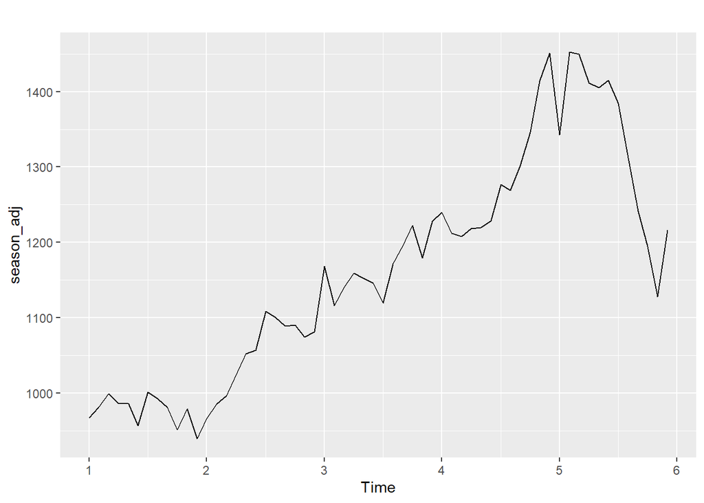

```r
decomp <- plastics %>% decompose(type="multiplicative")
season_adj <- plastics/decomp$seasonal
autoplot(season_adj)
```

To adjust for seasonality using the multiplicative decomposition, we can take the original data and divide it by the seasonal result of the decomposition.

## e. Change on observation to be an outlier (e.g., add 500 to one observation), and recompute the seasonally adjusted data. What is the effect of the outlier?

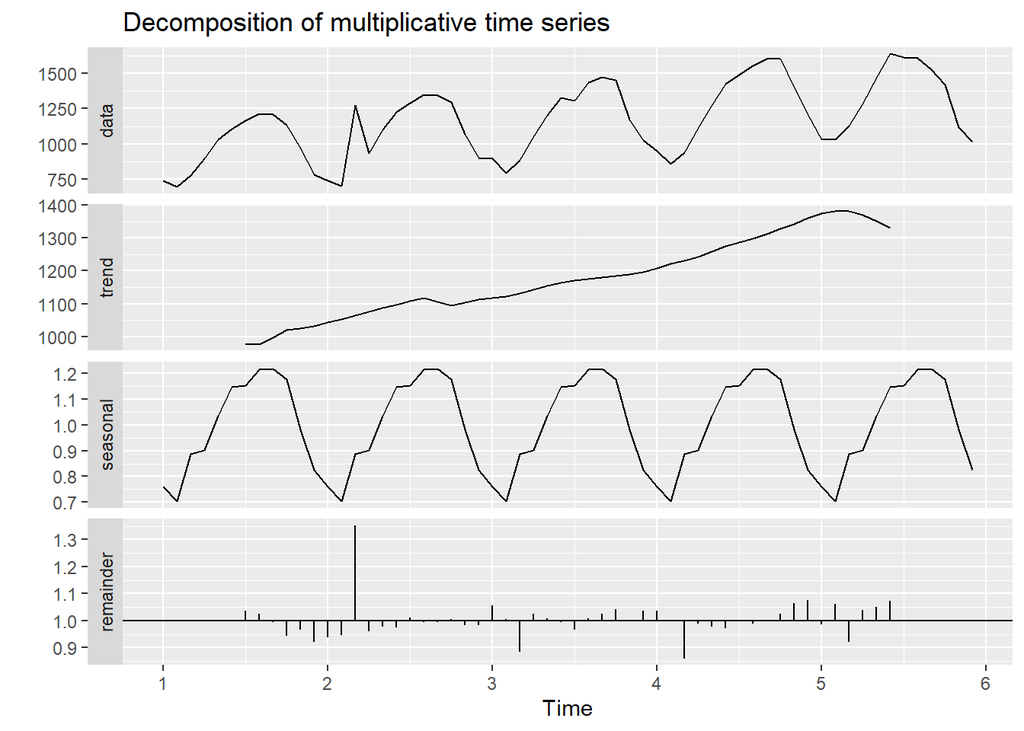

```r
plastics2 <- plastics
plastics2[15] <- plastics2[15] + 500
outlier_decomp <- decompose(plastics2, type="multiplicative")
autoplot(outlier_decomp)
```

## f. Does it make any difference if the outlier is near the end rather than in the middle of the time series?

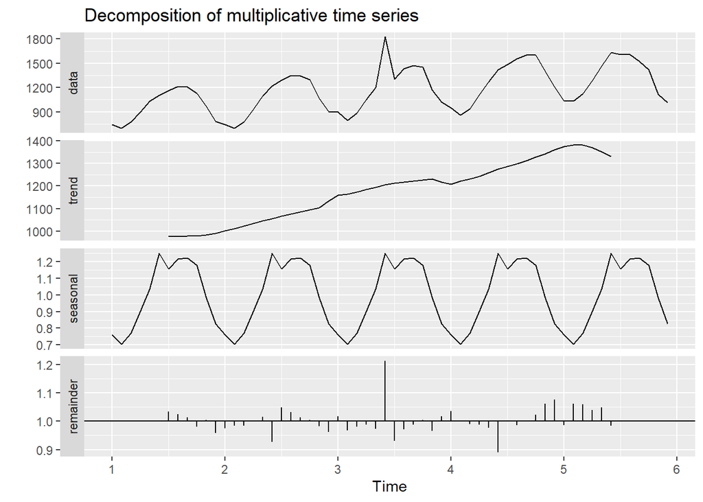

```r
plastics3 <- plastics
plastics3[30] <- plastics3[30] + 500
outlier_decomp3 <- decompose(plastics3, type="multiplicative")
autoplot(outlier_decomp3)
```

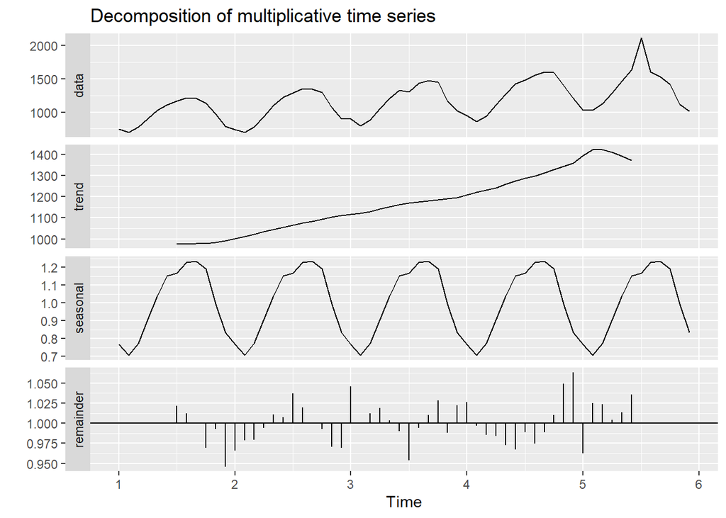

```r
plastics4 <- plastics
plastics4[55] <- plastics4[55] + 500
outlier_decomp4 <- decompose(plastics4, type="multiplicative")
autoplot(outlier_decomp4)
```

# Exercise 6.9 - 3

Recall your retail time series data (from Exercise 3 in Section 2.10). Decompose the series using X11. Does it reveal any outliers, or unsual features that you had not noticed previously?

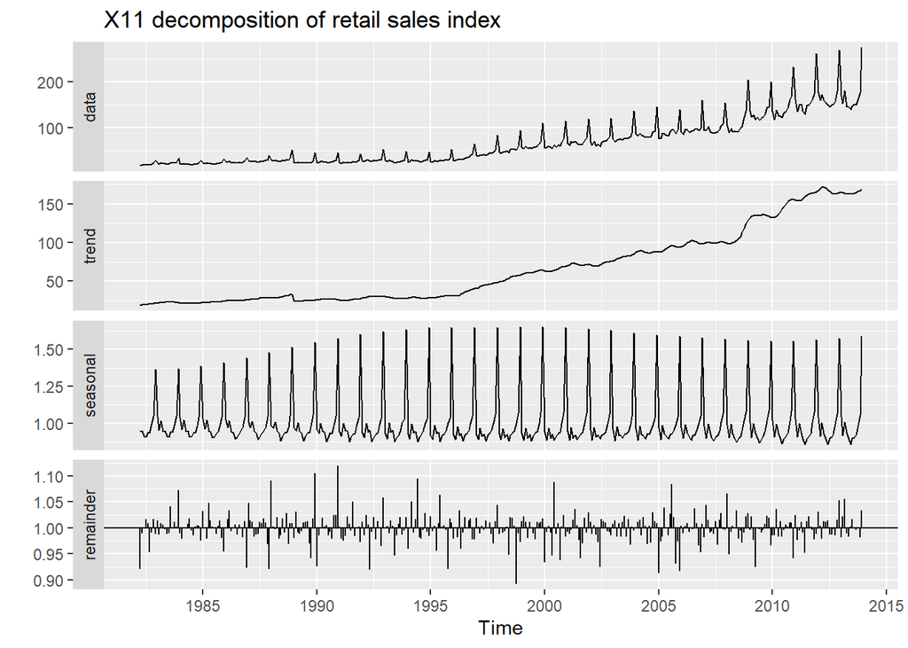

```r
retaildata <- readxl::read_excel("retail.xlsx", skip=1)

myts <- ts(retaildata[,"A3349414R"],
  frequency=12, start=c(1982,4))

myts %>% seas(x11="") -> fit

autoplot(fit) +
  ggtitle("X11 decomposition of retail sales index")
```

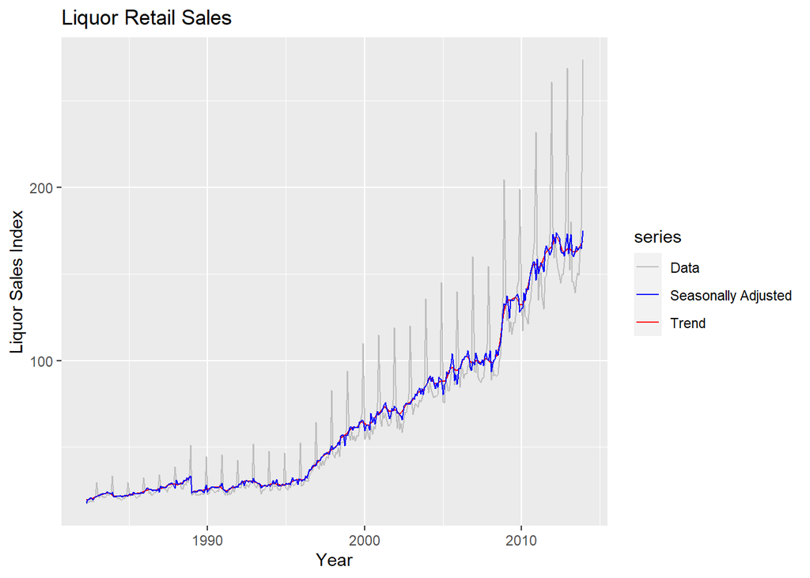

```r
autoplot(myts, series="Data") +
  autolayer(trendcycle(fit), series="Trend") +
  autolayer(seasadj(fit), series="Seasonally Adjusted") +
  xlab("Year") + ylab("Liquor Sales Index") +
  ggtitle("Liquor Retail Sales") +
  scale_colour_manual(values=c("gray","blue","red"),
             breaks=c("Data","Seasonally Adjusted","Trend"))
```